# R-INLA Blow Flies Analysis Tutorial

```r
knitr::opts_knit$set(root.dir = normalizePath(paste("D:","`Grad_Research","Rudy_RA_Work","R_Tutorial_Blow_Flies",sep="\\")))
```

## Overview

The purpose of this tutorial is to provide instructions for the implementation of a few basic procedures available through the R-INLA package. In order to make use of these procedures, we will need to also make use of several other R packages.

There are two primary operations that we will be employing in this tutorial:

- Creating an adjacency matrix for the three study areas in the provided data set
- Performing a Bayesian hierarchical Poisson model, specifically a BYM model

## Initialization

We will divide our preliminary procedures into two groups: directory setup and package loading.

### Directory Setup

We begin our tutorial by taking care of a few minor housekeeping procedures. First, we make sure that our entire R workspace is clear of variables using the rm() function (which is identical to the remove() function). And second, we set our working directory for R. What this is is essentially making sure that the program knows that the area it is performing calculations in is the folder where your data is.

```r
remove(list=ls())
setwd(paste("D:","`Grad_Research","Rudy_RA_Work","R_Tutorial_Blow_Flies",sep="\\"))
```

Note that the above directory is accurate only for my own computer. For yourself, what you will want to do is replace all of the above strings with strings representing each folder level you have saved your data into. For example, if the location of your file is C:\Users\Me\MyDocuments\Geography\This_Class, you will want the above setwd() to read: setwd(paste(“C:”,“Users”,“Me”,“MyDocuments”,“Geography”,“This_Class”,sep=“\\”)).

### Package Loading

With the directory business out of the way, we move on to loading all of the packages that we will be making use of in this tutorial. What the lapply() function does is takes the ‘X’ argument and applies the ‘FUN’ function argument to it. ‘character.only = TRUE’ is an argument passed to the require() (or library()) functions to indicate that the argument(s) being passed are character strings. What the require() function does is load a package into R so that you can use it in your code. Note that if you currently DO NOT have the listed package installed, the package load will fail. If this happens to you, then all you need to do is go to the “Tools” menu at the top of RStudio and click the first option, “Install Packages”: just write in the desired package, and after a brief period of loading, run the require function on the package again.

```r
required_packages <- c("INLA","splancs","sp","fields","maptools","lattice","abind","spdep","fastmatch")
lapply(X = required_packages, FUN =  require, character.only=TRUE)
```

```
[[1]]
[1] TRUE

[[2]]
[1] TRUE

[[3]]
[1] TRUE

[[4]]
[1] TRUE

[[5]]
[1] TRUE

[[6]]
[1] TRUE

[[7]]
[1] TRUE

[[8]]
[1] TRUE

[[9]]
[1] TRUE
```

```r
inla.setOption(scale.model.default=FALSE)
```

This last option adjusts the global options for the R-INLA package to not use the ‘default’ option for ‘scale.model’; the default option is to scale models to have generalized unit average variance.

## From Shapefile to Adjacency Matrix

> “Using inla.graph: produces the graph from a shape file with information on all the area boundaries and uses a combination of functions from different R packages.” -Rudy Banerjee

As Rudy explains in the quote above, what we’re now going to do is use a bunch of combinations of the loaded packages’ functions to convert the provided shapefile into an adjacency matrix, which will output to your “Plots” tab in Rstudio. To do this, we first will convert the shapefile to a special type of R dataframe, then will use that special dataframe object to generate a list of neighbors, and next will output an INLA .GRAPH into the folder. We will then define a variable to hold the location string for the outputted graph for use later. Finally, we will use the INLA package to read the graph and record it as a variable object, and then we will the image() function to output our adjacency matrix to our “Plots” tab for the world to see.

```r
z.gen <- readShapePoly("shp/all 3 overlay.shp")
```

```
use rgdal::readOGR or sf::st_read
```

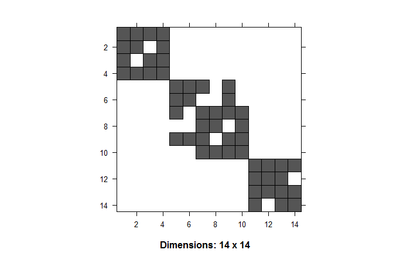

```r
temp <- poly2nb(z.gen)
nb2INLA("z.graph", temp)
z.adj <- paste(getwd(),"/z.graph",sep="")
H <- inla.read.graph(filename="z.graph")
image(inla.graph2matrix(H),xlab="",ylab="")
```

Just as in the previous section, we will need to consider our filepath locations in order for our functions to, well, function. So long as you extract your shp.zip file to the same hypothetical folder C:\Users\Me\MyDocuments\Geography\This_Class above, then you should be able to run the above code in your session without any trouble.

## The BYM Model

We now move on to the second primary operation in this tutorial: creating the BYM model. Our procedure will be as follows: we start by defining the formula we will use for our BYM model; next will read and record our provided .csv file (that is, our data being modeled) onto a variable; will then define the outcome variable, compute the expected outcome for this variable, and verify that both values have a common mean; and finally use the INLA package to perform our BYM model. We will finish our tutorial by outputting a summary of our model, using the convenient summary() function. Here we go.

```r
formula <- y ~ 1 + f(ID, model="bym",graph=z.adj)
library(readr)
Voronois <- read_csv("D:/`Grad_Research/Rudy_RA_Work/R_Tutorial_Blow_Flies/shp/Overlay.csv")
y <- Voronois$TotalPhormia
E <- Voronois$Area * sum(y)/sum(Voronois$Area)
if (isTRUE(abs(mean(y)-mean(E))<1e-10)){
  print("mean(y) and mean(E) are the same")
}
```

```
[1] "mean(y) and mean(E) are the same"
```

```r
mod.Z <- inla(formula,family="poisson",
                         data=Voronois,E=E,
                         control.compute=list(dic=TRUE))
summary(mod.Z)
```

```
Call:
c("inla(formula = formula, family = \"poisson\", data = Voronois, ",  "    E = E, control.compute = list(dic = TRUE))")

Time used:
 Pre-processing    Running inla Post-processing           Total
          0.322           0.269           0.060           0.651

Fixed effects:
               mean     sd 0.025quant 0.5quant 0.975quant    mode kld
(Intercept) -0.1707 0.2893    -0.7471  -0.1704      0.403 -0.1698   0

Random effects:
Name      Model
 ID   BYM model

Model hyperparameters:
                                          mean        sd 0.025quant  0.5quant 0.975quant     mode
Precision for ID (iid component)        0.9943    0.3672     0.4342    0.9441      1.857   0.8421
Precision for ID (spatial component) 1851.1906 1832.0299   126.8998 1310.2040   6694.380 346.3936

Expected number of effective parameters(std dev): 13.91(0.031)
Number of equivalent replicates : 1.006

Deviance Information Criterion (DIC) ...: 127.90
Effective number of parameters .........: 13.92

Marginal log-Likelihood:  -97.68
Posterior marginals for linear predictor and fitted values computed
```

In the above chunk, the variable ‘y’ is the outcome variable, and the variable ‘E’ is the expected outcome of this variable. The if statement simply outputs confirmation as to whether or not your mean(y) and mean(E) are the same value (well, technically-speaking, not that they are the same, but that their difference is a neglible artifact of rounding errors). Lastly, as always, be aware that the read_csv() function is reading a folder location, specifically *my* folder location, meaning that you will once again have to replace the above character string with the one specific to where you have your files saved on your computer.